# Mondal_Mondal_memo

Ralitza Mondal

November 1, 2019

# Introduction

Cereals are a good healthy quick meal for all people in the world. But the market provides only three types of producers: 1. General Mills 2. Kelloggs and 3.Post. As an intern at General Mills, I will illustrate where we stand in the market today and why it is important. I was given a data set of 21850 recorded transactions. I had unique store and product numbers given to me with each products’s price,volume and unit sold. Additionally, each recorded transaction had the product name and its corresponding flavor recorded in the transaction data set. These observations take place in 52 weeks. During this time, promotions and advertisements were made on each brand to boost sales and revenue. Our main focus today would be how the promotions and advertisements affect revenue and price throughtout the 52 weeks.

First of all we want to see how General Mills is performing compared to its competitors and what strategies are we using.

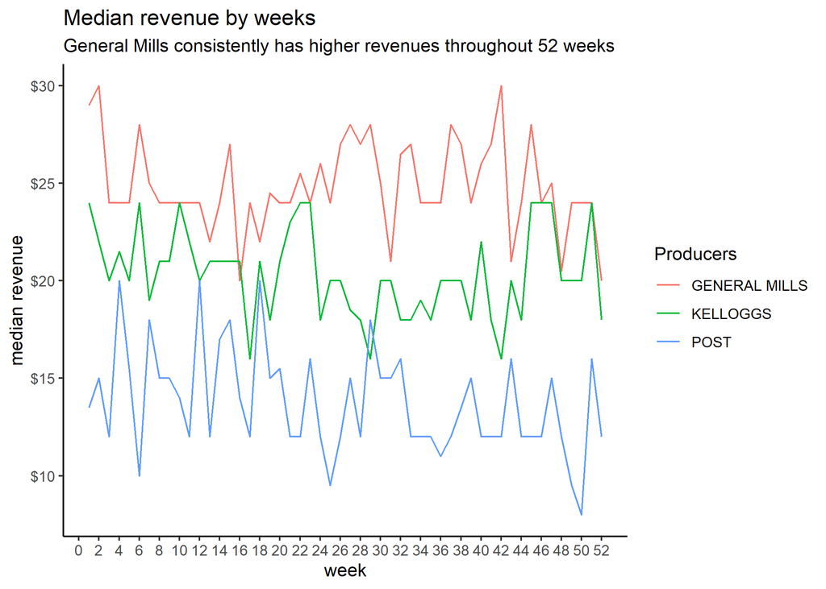

In the first two quarters, 26 weeks, General Mills advertised for Coca Puffs where Kelloggs did not advertise for cocoa puffs’s direct substitute, Kellog’s Cocoa Krispies

General Mills did not advertise for the same regular flavour of Kix when they knew that Kelloggs already dominates with Frosted Flakes in the regular flavour consistently from the start of the 52 weeks

Lucky charm of General Mills dominate in advertisement, both A and B, making it more popular than Kellogg’s Smart Tart and Kellogg’s K in the same flavor

Post only produces regular flavor cereal, which even with advertisements and promotions struggle to compete with Kelloggs and General Mills in revenue and sale.

We are curious to know how promotion and advertisements affect the General Mill’s brand relative to our competitor’s brand. Our assumption is that higher promotions will lead to higher units sold and advertisements which lead to higher demand for our brands and hence cause our prices to rise. The following two finding will give us and insight of how significant is our assumption.

# Finding 1

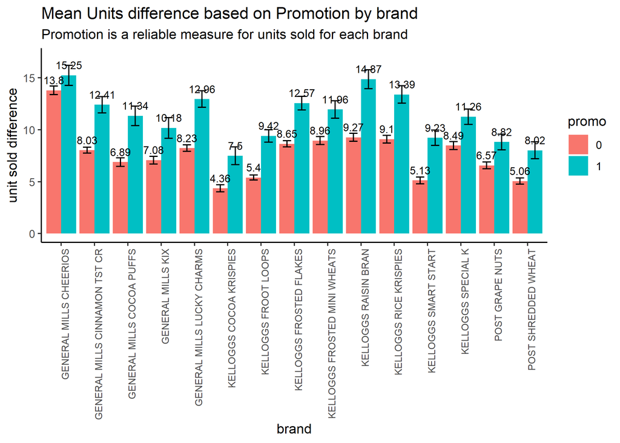

The mean unit sold difference between having promotion and not having promotion is reliably greater than 1. This means that having promotion on each brand for all firms increases units sold reliably than not having promotion.The error width for each of the bar is bigger for promotion meaning that prices deviate more with discount which makes sense. General Mill’s brand units sold increases as reliably as its competitiors with promotion.

# Finding 2

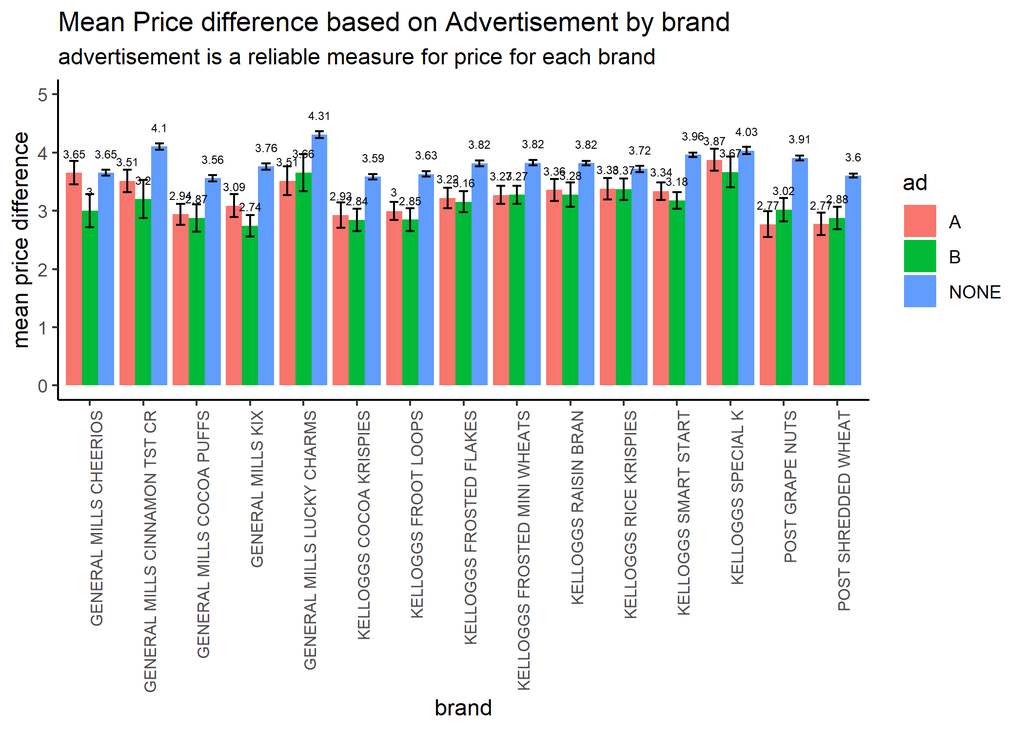

# Conclusion

The summary to take away is that promotion has a strong impact on units sold and advertisements make consumer prices go down. Another way is to analyze the revenue by promotion and advertisement which I have done in my Technical Appendix. Promotion and advertisment also affect median revenue of each brand positively.But their impact on revenue is not statistically insignificant. For now, I will leave my quick analysis here. Please contact me if you have questions. You can reach me at rmondal@seattleu.edu. I can provide Technical Appendix with my complete analysis and the data if you would like more detail. Sincerely, Ralitza